# Analysing cultural frequency data: neutral theory and beyond

Enrico Crema

13 August 2018

# Introduction and Setup

This markdown document contains the R script for reproducing some of the figures of the book chapter “Analysing cultural frequency data: neutral theory and beyond” by A.Kandler and E.Crema. The main functions for running the simulations described in the chapter can be installed as an R package with following command:

```r
devtools::install_github("ercrema/CultEvoChapter")
```

In order to fully reproduce the figures in the text the following R packages must also be loaded:

```r
library(CultEvo)
library(plotrix)
library(LaplacesDemon)
library(ggplot2)
library(ggridges)
```

We then set the number of repetitions:

```r
nsim = 100
```

All figures on the book chapter are all based on 1,000 simulation repetitions. To achieve exactlt the same output `nsim` should be set to 1000, although it is worth noting that this will require considerable running time.

# Figure 1: Diversity and Battleship Curves

The function `transmission()` executes unbiased and frequency biased transmission returning a variety of statistics. The example below compares the time-series of the Simpson’s diversity index against the the so-called battle-ship curve of the most common variants. First we run the model and extract relevant outputs:

```r
#set random seed
set.seed(123)
#run simulation
res.fig1=transmission(timesteps=2000,mu=0.005,N=500,warmUp=1000,bias=0,raw=TRUE)
#extract matrix of frequencies
mat.fig1=res.fig1$rawMatrix
#compute proportions
pmat.fig1=prop.table(mat.fig1,1)
#reorder matrix based on total frequencies
pmat.fig1=pmat.fig1[,order(apply(pmat.fig1,2,sum),decreasing=TRUE)]
#extract observed diversity time-series
divTS = res.fig1$obs.div
#extract expected diversity under neutrality
divExp = res.fig1$exp.div
```

The matrix `pmat.fig1` now contains the frequencies of each variant at each timestep, the vector `divTS` contains the time-series of Simpson’s diversity index, while `divExp` contains the expected diversity under neutrality, equivalent to $1-\frac{1}{2N\mu+1}$. We are now ready to make our figure:

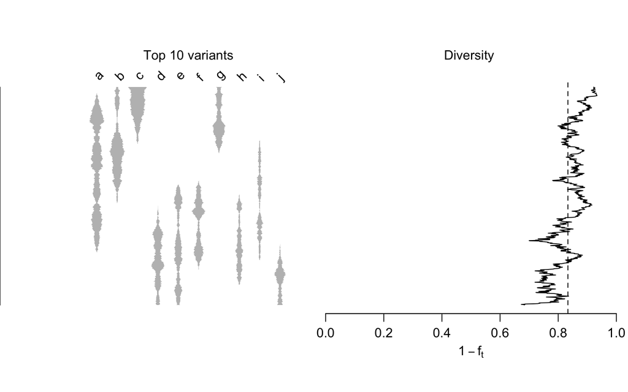

```r
#make figure
par(mfrow=c(1,2))

#left panel
par(mar=c(5,0,5,0))
topVariants = 10 #show only the 10 most frequent variants
battleship.plot(pmat.fig1[,1:topVariants],yaxlab="",xaxlab= letters[1:topVariants],border=NA,col="grey",mar=c(5,5,5,1))
axis(2,padj=0.5)
mtext(side=2,"time",line=2)
mtext(side=3,paste0("Top ",topVariants," variants"),line=1)
#right panel
par(mar=c(5,0,5,0))
plot(divTS,1:1000,type="l",xlab="",axes=F,ylab="",xlim=c(0,1))
abline(v=divExp,lty=2)
axis(side=1,padj=-0.5)
mtext(side=1,expression(1-f[t]),line=2)
mtext(side=3,"Diversity ",line=1)
```

# Figure 2: Effect of sampling window for computing reliable estimates of the turn-over rate

```r
#set random seed
set.seed(123)
#set sampling window from 10 to 500, all with 1000 generations of warmup
timesteps <- c(seq(1010,1100,10),1200,1500)

#create list for storing the results:
res.fig2 = matrix(NA,nrow=nsim,ncol=length(timesteps))

#execute transmission() and extract estimates of the exponent x (here named b):

for (i in 1:length(timesteps))
{
  res.fig2[,i]=replicate(transmission(timesteps=timesteps[i],mu=0.01,N=500,warmUp=1000,bias=0,raw=F,top=10)$b,n=nsim)
}

#Extract summary statistics (median, first and third quartile) from each setting of the sampling window
mid.fig2=apply(res.fig2,2,median)
lo.fig2=apply(res.fig2,2,quantile,0.25)
up.fig2=apply(res.fig2,2,quantile,0.75)
```

We can now visualise our output. The object `res.fig2` contains the estimates of $x$ under different sampling window size, so a quick way to plot the simulation output is to just make a box and whisker plot:

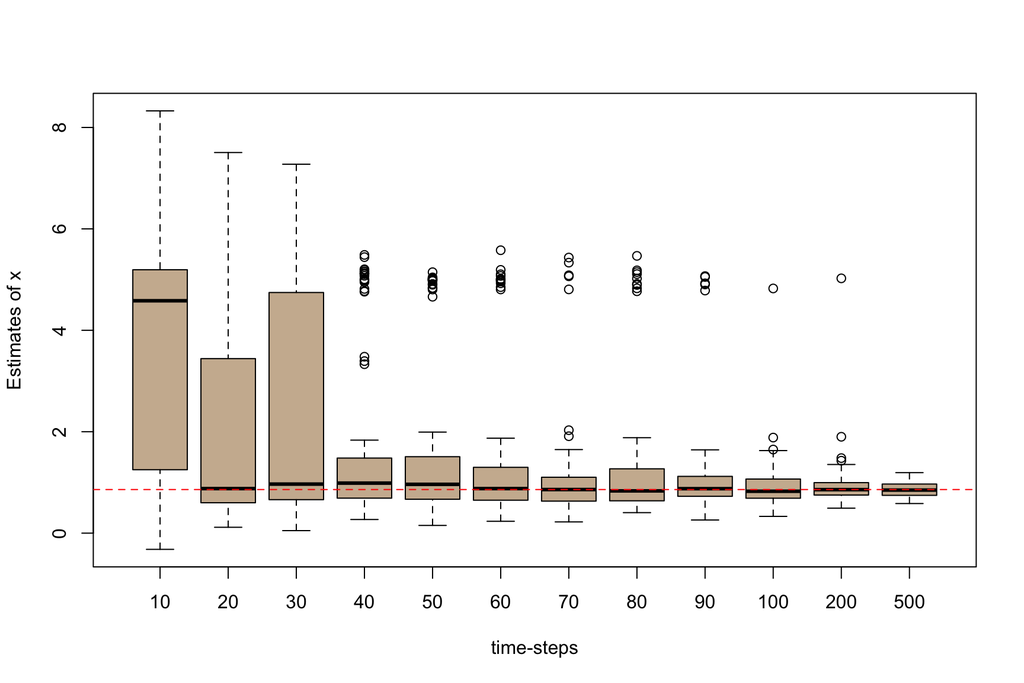

```r
boxplot(res.fig2,names=timesteps-1000,xlab="time-steps",ylab="Estimates of x",col="bisque3")
abline(h=0.86,col=2,lty=2) #expected value of x
```

The code below is instead the one used in the manuscript:

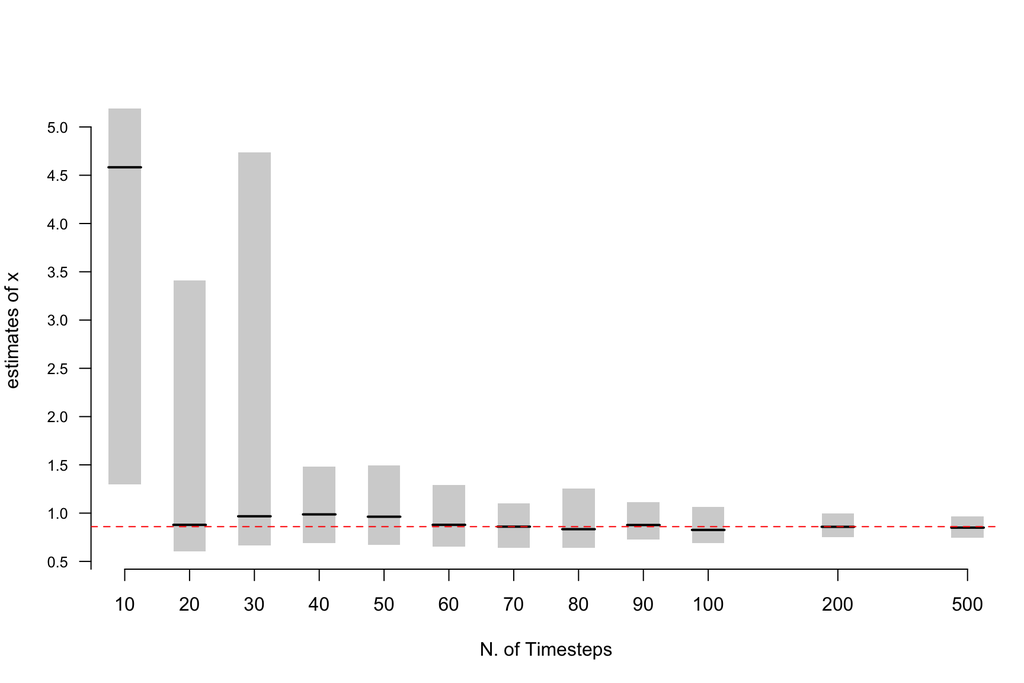

```r
#Plot results using rect() and unqeual spacing along the x-axis
par(mar=c(5,4,4,1))
plot(1:14,1:14,ylim=c(min(lo.fig2),max(up.fig2)),type="n",axes=F,xlab="N. of Timesteps",ylab="estimates of x")

for (x in 1:10)
{
    rect(xleft=x-0.25,xright=x+0.25,ybottom=lo.fig2[x],ytop=up.fig2[x],col="lightgrey",border=NA)
    lines(x=c(x-0.25,x+0.25),y=c(mid.fig2[x],mid.fig2[x]),lwd=2)
}

x=11
rect(xleft=12-0.25,xright=12+0.25,ybottom=lo.fig2[x],ytop=up.fig2[x],col="lightgrey",border=NA)
lines(x=c(12-0.25,12+0.25),y=c(mid.fig2[x],mid.fig2[x]),lwd=2)

x=12
rect(xleft=14-0.25,xright=14+0.25,ybottom=lo.fig2[x],ytop=up.fig2[x],col="lightgrey",border=NA)
lines(x=c(14-0.25,14+0.25),y=c(mid.fig2[x],mid.fig2[x]),lwd=2)

# add axes
axis(side=2,at=seq(0,5,0.5),cex.axis=0.8,las=2)
axis(side=1, at=c(1:10,12,14),labels=c(seq(10,100,10),200,500),cex=0.9)

# show the expected value of b under neutrality
abline(h=0.86,lty=2,col="red")
```

# Figure 3: Effect of a Heterogenous population of learners

To execute a simulation with an heterogenous population of learners we use the function `heteroPopTransmission()` which enables to define the frequency bias of each individual at each generation as a random draw from a normal distribution with a user defined mean (argument `bmean`) and standard deviation (argument `bsd`). Here we explore a scenario where the mean is hold constant to 0 (hence on average the learners engage into an unbiased transmission), but the standard deviation is varied and explored.

```r
#set random seed
set.seed(123)
#set number of generations
ngen=1000
#set parameter to vary (bsd)
bsd = c(0,0.1,0.2)
#define matrix for storing the results
res.fig3 = matrix(NA,nrow=nsim,ncol=length(bsd))


#run simulation with three different values of bsd
for (i in 1:length(bsd))
{
  res.fig3[,i]=replicate(heteroPopTransmission(N=500,bmean=0,bsd=bsd[i],mu=0.01,timesteps=ngen)[ngen],n=nsim)
}
```

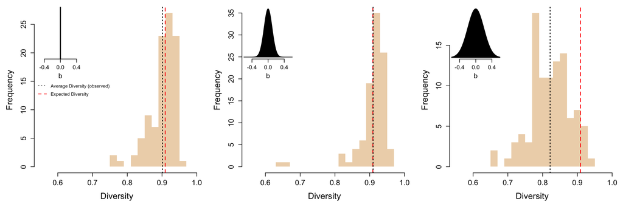

```r
# Setup layout
mat=matrix(c(1,4,4,4,2,5,5,5,3,6,6,6),nrow=2,ncol=6)
layout(mat=mat,heights=c(0.45,0.55),widths=c(0.45,0.55,0.45,0.55,0.45,0.55))

# Visualise distribution of learners' frequency bias under each setting
par(mar=c(5,5,1,1))
plot(0,1,type="n",axes=F,xlab="",ylab="",xlim=c(-0.6,0.6))
lines(x=c(0,0),y=c(0,2),lwd=2)
axis(1,at=c(-0.4,0,0.4),padj=-0.5)
mtext("b",1,line=2,cex=0.8)

par(mar=c(5,5,1,1))
xx=seq(-0.6,0.6,length.out=1000)
yy=dnorm(x=xx,sd=0.1)
plot(xx,yy,type="n",axes=F,xlab="",ylab="")
polygon(c(xx,rev(xx)),c(yy,rep(0,1000)),col="black")
axis(1,at=c(-0.4,0,0.4),padj=-0.5)
mtext("b",1,line=2,cex=0.8)

par(mar=c(5,5,1,1))
xx=seq(-0.6,0.6,length.out=1000)
yy=dnorm(x=xx,sd=0.2)
plot(xx,yy,type="n",axes=F,xlab="",ylab="")
polygon(c(xx,rev(xx)),c(yy,rep(0,1000)),col="black")
axis(1,at=c(-0.4,0,0.4),padj=-0.5)
mtext("b",1,line=2,cex=0.8)


# Show simulation result
par(mar=c(5,5,1,1.2))
hist(res.fig3[,1],breaks=seq(0.55,1,0.02),border=NA,col="bisque2",xlab="Diversity",main="",cex.lab=1.5,cex.axis=1.3)
abline(v=1-(1/(500* 0.01*2+1)),lty=2,col=2,lwd=1.5)
abline(v=mean(res.fig3[,1]),lty=3,lwd=1.5)
legend("left",legend=c("Average Diversity (observed)","Expected Diversity"),col=c(1,2),lty=c(3,2),bty="n",cex=0.8,y.intersp=1.5)

hist(res.fig3[,2],breaks=seq(0.55,1,0.02),border=NA,col="bisque2",xlab="Diversity",main="",cex.lab=1.5,cex.axis=1.3)
abline(v=1-(1/(500* 0.01*2+1)),lty=2,col=2,lwd=1.5)
abline(v=mean(res.fig3[,2]),lty=3,lwd=1.5)

hist(res.fig3[,3],breaks=seq(0.55,1,0.02),border=NA,col="bisque2",xlab="Diversity",main="",cex.lab=1.5,cex.axis=1.3)
abline(v=1-(1/(500* 0.01*2+1)),lty=2,col=2,lwd=1.5)
abline(v=mean(res.fig3[,3]),lty=3,lwd=1.5)
```

# Figure 4: Effect of non-equilibrium

The argument `bias` in the function `transmission()` allows for a time-varying frequency bias. The code below explores how a temporary shift from an unbiased transmission to an anti-conformist transmission affects the observed diversity of the cultural variants.

```r
#set random seed
set.seed(123)
#define bias parameter
bias.eq = 0
bias.neq = c(rep(0,1500),rep(0.5,10),rep(0,490))


#run simulations
res.fig4.eq=matrix(replicate(transmission(timesteps=2000,mu=0.005,N=500,warmUp=1000,bias=bias.eq,raw=TRUE)$obs.div[401:900],n=nsim),nrow=500,ncol=nsim)

res.fig4.neq=matrix(replicate(transmission(timesteps=2000,mu=0.005,N=500,warmUp=1000,bias=bias.neq,raw=TRUE)$obs.div[401:900],n=nsim),nrow=500,ncol=nsim)

# Compute Expected Diversity
expected.diversity = 1 - (1/(2*500*0.005+1))
```

```r
par(mfrow=c(2,1),mar=c(1,5,5,2))

plot(1:500,res.fig4.eq[,1],ylim=c(0.4,1),type="n",xlab="",ylab="Simpson's Diversity",xaxs="i",axes=F,las=2)
text(480,0.5,"a",cex=1.5)
polygon(x=c(1:500,500:1),y=c(apply(res.fig4.eq,1,quantile,prob=0.025),rev(apply(res.fig4.eq,1,quantile,prob=0.975))),col=rgb(1,0,0,0.2),border=NA)
apply(res.fig4.eq,2,lines,col=rgb(0,0,0,0.01),x=1:500)
```

```r
lines(1:500,apply(res.fig4.eq,1,mean),col="red")
abline(h=expected.diversity,col="black",lty=2)
axis(2,at=seq(0,1,0.2),las=2,hadj=0.8)

par(mar=c(6,5,0,2))

plot(1:500,res.fig4.neq[,1],ylim=c(0.4,1),type="n",xlab="time",ylab="Simpson's Diversity",xaxs="i",axes=F,las=2)
polygon(x=c(1:500,500:1),y=c(apply(res.fig4.neq,1,quantile,prob=0.025),rev(apply(res.fig4.neq,1,quantile,prob=0.975))),col=rgb(1,0,0,0.2),border=NA)
apply(res.fig4.neq,2,lines,col=rgb(0,0,0,0.01),x=1:500)
```

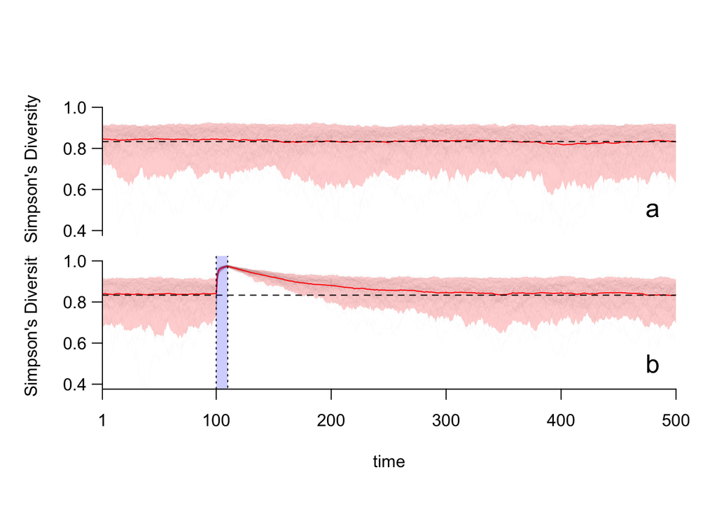

```r
lines(1:500,apply(res.fig4.neq,1,mean),col="red")
abline(h=expected.diversity,col="black",lty=2)
rect(xleft=100,xright=110,ybottom=-100,ytop=100,col=rgb(0,0,1,0.2),lty=3)
text(480,0.5,"b",cex=1.5)
axis(2,at=seq(0,1,0.2),las=2,hadj=0.8)
axis(1,at=c(1,100,200,300,400,500))
```

# Figure 7: Posterior Distribution of the Merzbach Assemblage Analysis.

```r
# load data
data("post_b_merzbach")
```

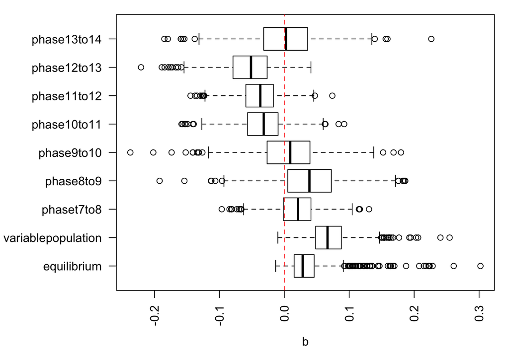

```r
# Simple boxplot:
par(mar=c(5,8,1,1))
boxplot(post_b_merzbach,horizontal=T,las=2,xlab="b")
abline(v=0,lty=2,col=2) #unbiased transmission
```

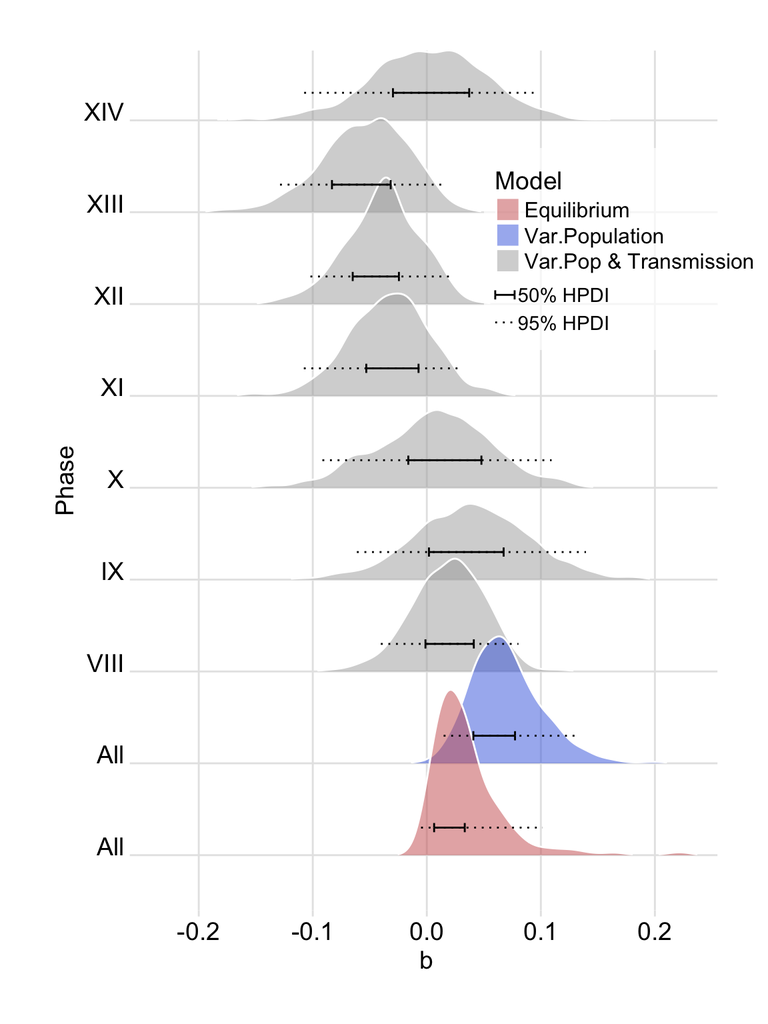

```r
#Extract 50 and 95$ HPDI
hpd50 = t(apply(post_b_merzbach,2,p.interval,prob=0.5))
hpd95 = t(apply(post_b_merzbach,2,p.interval,prob=0.95))


#Restructure into data.frame
data=rbind.data.frame(
data.frame(Model="Equilibrium",b=post_b_merzbach[,1],Phase="All(Eq)"),
data.frame(Model="Var.Population",b=post_b_merzbach[,2],Phase="All(S.Eq)"),
data.frame(Model="Var.Pop & Transmission",Phase="VIII",b=post_b_merzbach[,3]),
data.frame(Model="Var.Pop & Transmission",Phase="IX",b=post_b_merzbach[,4]),
data.frame(Model="Var.Pop & Transmission",Phase="X",b=post_b_merzbach[,5]),
data.frame(Model="Var.Pop & Transmission",Phase="XI",b=post_b_merzbach[,6]),
data.frame(Model="Var.Pop & Transmission",Phase="XII",b=post_b_merzbach[,7]),
data.frame(Model="Var.Pop & Transmission",Phase="XIII",b=post_b_merzbach[,8]),
data.frame(Model="Var.Pop & Transmission",Phase="XIV",b=post_b_merzbach[,9]))

#make joyplot
g=ggplot(data, aes(x = b, y = Phase,fill=Model)) +
geom_density_ridges(rel_min_height=0.005,alpha=0.5,color="white")+scale_fill_manual(values=c("indianred","royalblue","darkgrey"))+
  theme_ridges(center_axis_labels = TRUE)+
    theme(plot.margin = unit(c(1,1,1,1), "cm"),legend.position = c(0.6, 0.8))+scale_y_discrete(labels=c("All","All","VIII","IX","X","XI","XII","XIII","XIV"))+coord_cartesian(xlim = c(-0.25, 0.25)) +  scale_x_continuous(expand = c(0.01, 0))+
    annotate("rect",xmin = 0.05, xmax = 2.5, ymin = 6.5, ymax = 8.7,alpha=0.7,fill="white")+
           annotate("segment",x = 0.06, xend = 0.077, y = 7.1, yend = 7.1)+
           annotate("segment",x = 0.06, xend = 0.06, y = 7.1, yend = 7.05)+
           annotate("segment",x = 0.077, xend = 0.077, y = 7.1, yend = 7.05)+
            annotate("segment",x = 0.06, xend = 0.06, y = 7.1, yend = 7.15)+
           annotate("segment",x = 0.077, xend = 0.077, y = 7.1, yend = 7.15)+
           annotate("text",x = 0.12,y = 7.1,label="50% HPDI")+
           annotate("segment",x = 0.06, xend = 0.078, y = 6.8, yend = 6.8,linetype="dotted")+
           annotate("text",x = 0.12,y = 6.8,label="95% HPDI")

#add HPDI intervals
  for (i in 1:9)
  {
    g = g +
    annotate("segment",x = hpd50[i,1], xend = hpd50[i,2], y = i+0.3, yend = i+0.3,lwd=0.5)+
    annotate("segment",x = hpd50[i,1], xend = hpd50[i,1], y = i+0.3, yend = i+0.25,lwd=0.5)+
    annotate("segment",x = hpd50[i,2], xend = hpd50[i,2], y = i+0.3, yend = i+0.25,lwd=0.5)+
    annotate("segment",x = hpd50[i,1], xend = hpd50[i,1], y = i+0.3, yend = i+0.35,lwd=0.5)+
    annotate("segment",x = hpd50[i,2], xend = hpd50[i,2], y = i+0.3, yend = i+0.35,lwd=0.5)+
    annotate("segment",x = hpd95[i,1], xend = hpd95[i,2], y = i+0.3, yend = i+0.3, linetype="dotted",lwd=0.5)
  }
g
```